# Supplemental Assignment

Ajinkya Sheth

February 14, 2019

## a) (5 pt) Perform an exploratory analysis of the father and son heights. What does the relationship look like? Would a linear model be appropriate here?

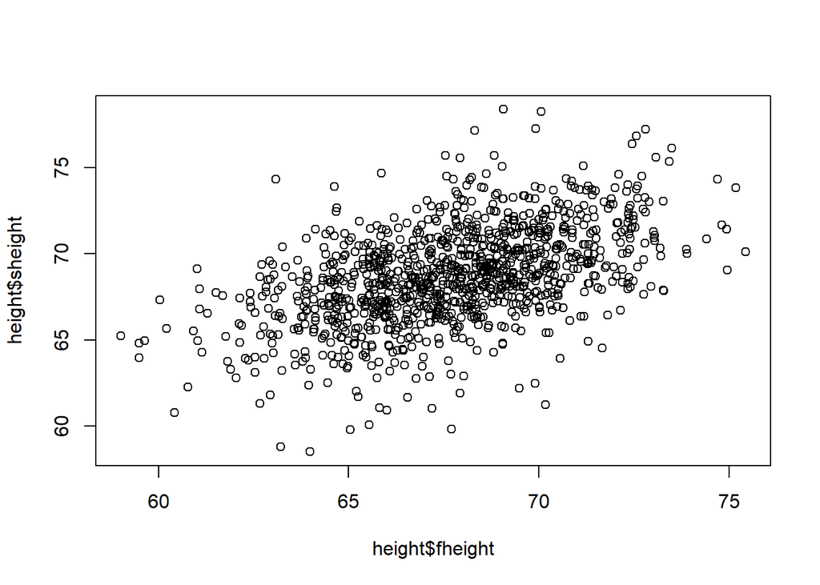

```r
plot(height$fheight,height$sheight)
```

### Scatter plot between father’s height and son’s height shows that most data points are concentrated in the middle and linear model could be a rough generalization for the data

## b) (5 pt) Use the lm function in R to fit a simple linear regression model to predict son’s height as a function of father’s height. Write down the model,

## ysheight = β0 + β1 x fheight

## filling in estimated coefficient values and interpret the coefficient estimates.

```r
mod <- lm(sheight ~ fheight, data = height)
summary(mod)
```

```
##
## Call:
## lm(formula = sheight ~ fheight, data = height)
##
## Residuals:
##     Min      1Q  Median      3Q     Max
## -8.8772 -1.5144 -0.0079  1.6285  8.9685
##
## Coefficients:
##             Estimate Std. Error t value Pr(>|t|)
## (Intercept) 33.88660    1.83235   18.49   <2e-16 ***
## fheight      0.51409    0.02705   19.01   <2e-16 ***
## ---
## Signif. codes:  0 '***' 0.001 '**' 0.01 '*' 0.05 '.' 0.1 ' ' 1
##
## Residual standard error: 2.437 on 1076 degrees of freedom
## Multiple R-squared:  0.2513, Adjusted R-squared:  0.2506
## F-statistic: 361.2 on 1 and 1076 DF,  p-value: < 2.2e-16
```

### Interpretation: A 1 inch increase in father’s height leads to 0.51 inch incease in Son’s height

## c) (5 pt) Find the 95% confidence intervals for the estimates. You may find the confint() command useful.

```r
confint(mod)
```

```
##                  2.5 %     97.5 %
## (Intercept) 30.2912126 37.4819961
## fheight      0.4610188  0.5671673
```

## d) (5 pt) Produce a visualization of the data and the least squares regression line.

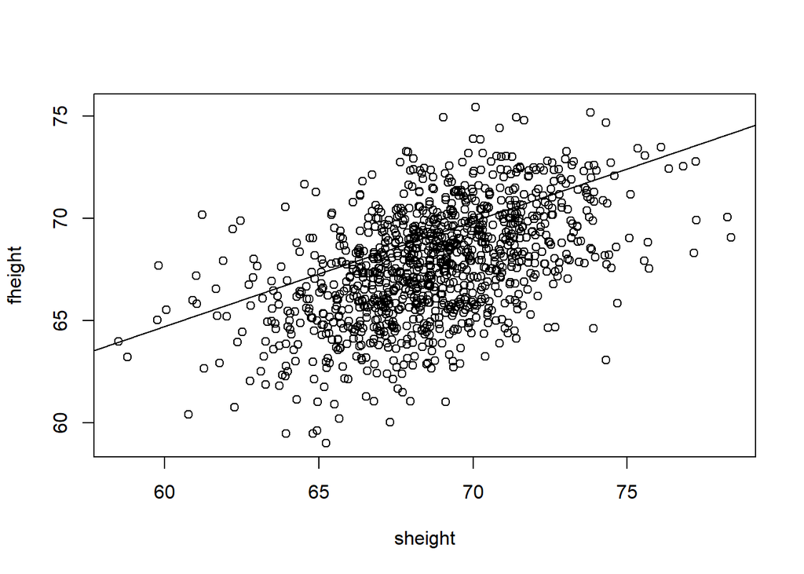

```r
plot(mod$model)
abline(mod)
```

## e) (5 pt) Produce a visualization of the residuals versus the fitted values. (You can inspect the elements of the linear model object in R using names()). Discuss what you see. Do you have any concerns about the linear model?

```r
names(mod)
```

```
##  [1] "coefficients"  "residuals"     "effects"       "rank"
##  [5] "fitted.values" "assign"        "qr"            "df.residual"
##  [9] "xlevels"       "call"          "terms"         "model"
```

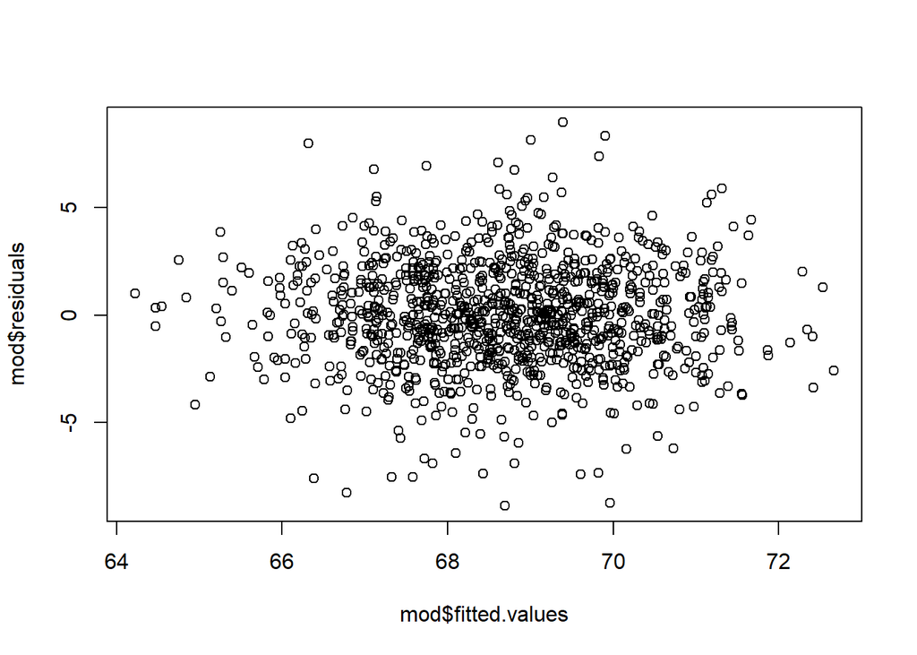

```r
plot(mod$fitted.values,mod$residuals)
```

### Most of the residuals seem to be concentrated between -5 and 5 units. No major concerns over linear model

```r
fh <- data.frame(fheight = c(50,55,79,75,90))
res <- predict(lm(sheight ~ fheight, data = height), fh)
res
```

```
##        1        2        3        4        5
## 59.59126 62.16172 74.49995 72.44358 80.15498
```